# FluxCore: Grandfather Paradox Resolution — A Dynamical Framework

**Mounir Djebassi**  
*Independent Researcher | ORCID: 0009-0009-6871-7693*  
*Foundations of Physics — Letter Submission 2026*

> **Associated Framework:** [FluxCore DOI: 10.5281/zenodo.18985830](https://doi.org)

**Axiom:** The "Grandfather Paradox" is a mathematical artifact of static geometry. In a **dynamical causal system** governed by FluxCore, the paradox is a **transient state** that relaxes toward a self-consistent global equilibrium.

## Abstract

The grandfather paradox has persisted as a fundamental challenge in theoretical physics primarily because it has been treated as a discrete problem of formal logic within static geometries. We propose a radical shift in perspective by applying the **FluxCore framework**, where causal consistency is no longer a constraint to be enforced, but an **emergent attractor** of a dynamical scalar field $\phi$ governed by the nonlinear evolution equation:

$$ \frac{\partial \phi}{\partial t} = \frac{\phi_{eq} - \phi}{\tau} + D\nabla^2\phi - k \rho |\nabla\phi|^\alpha $$

**Keywords:** grandfather paradox, FluxCore, causal field, dynamical systems, emergent coherence, Vortex T, time travel.

## 1. Introduction

The grandfather paradox, first popularized in science fiction [Barjavel, 1943], presents a fundamental challenge to the temporal structure of spacetime. The classic recursive loop—where a time traveler’s action (killing a grandfather) prevents their own birth, thus negating the possibility of the trip itself—leads to a formal logical contradiction.

Historically, the scientific community has proposed several mechanisms to resolve this impasse, as summarized in Table I:

| Resolution Mechanism | Key Proponent | Operational Principle |
| --- | --- | --- |
| **Chronology Protection** | Hawking (1992) | Global prohibition of closed timelike curves (CTCs). |
| **Many-Worlds Interpretation** | Everett (1957) | Divergence into orthogonal, non-interfering timelines. |
| **Self-Consistency Principle** | Novikov (1992) | Constraints on initial conditions to allow only consistent loops. |

**Table I.** Classical paradigms for resolving temporal paradoxes.

While these approaches are robust within a purely logical or geometric framework, they treat the timeline as a static entity. The **FluxCore** framework proposes a radical departure from these static interpretations by asking a fundamental question: **What if the timeline is a dynamical system governed by field dissipation rather than a set of logical constraints?**

By reinterpreting causal coherence as a stationary state of a nonlinear evolution equation, we demonstrate that paradoxes are not logical impossibilities, but unstable transients that the system naturally dampens.

## 2. The FluxCore Causal Field Framework

### 2.1 The Dynamical Evolution Equation

We formalize causal consistency as a continuous scalar field $\phi(\mathbf{r}, t)$. The evolution of this field is governed by the nonlinear FluxCore equation:

$$ \frac{\partial \phi}{\partial t} = \frac{\phi_{eq} - \phi}{\tau} + D\nabla^2\phi - k \rho |\nabla\phi|^\alpha \qquad (1) $$

### 2.2 Causal Interpretation of Physical Terms

Each mathematical operator in Eq. (1) represents a specific mechanism for maintaining temporal integrity, as detailed in Table II.

[output not shown]

**Table II.** Functional mapping of the FluxCore equation to causal dynamics.

### 2.3 Causal Attractors and Transient States

In this framework, the equilibrium state $\phi_{eq}$ represents a fully coherent timeline where all necessary events coexist. A paradoxical action, such as the attempted elimination of a biological ancestor, is treated as a transient perturbation $\delta\phi$.

The "Hidden Force" term is particularly critical here: a paradox creates an infinite gradient ($|\nabla\phi| \to \infty$) at the point of contradiction. This triggers a massive dissipative response that drives the field back to $\phi_{eq}$.

**Table III. The Rubik’s Cube Analogy for Causal Correction**

| Rubik’s Cube System | FluxCore Causal Field |
| --- | --- |
| **Scrambled state** ($g \neq id$) | Perturbed field ($\phi \neq \phi_{eq}$) |
| **Correction moves** $\to id$ | $\partial \phi / \partial t$ drives $\phi \to \phi_{eq}$ |
| **Solved Cube** | Causal Coherence (Attractor) |

## 3. Numerical Simulation: Temporal Restoration

### 3.1 Experimental Setup

To demonstrate the self-correcting nature of the FluxCore field, we simulated a 1D causal chain of $N=10$ discrete events. Causal coherence is represented by the stationary state $\phi_{eq} = 1.0$. The "Grandfather Paradox" is modeled as a Dirac-like perturbation at $t=1$, where the state of a critical ancestor (index 2) is forced to $\phi = 0.0$ (event suppression).

### 3.2 Dynamics of Recovery

The system's evolution was integrated using an explicit scheme with $\Delta t = 0.1$. As shown in Figure 1, the "Hidden Force" ($|\nabla\phi|^\alpha$) and the relaxation term ($\tau$) act immediately upon the localized causal break.

The simulation reveals a rapid **causal re-healing** process:

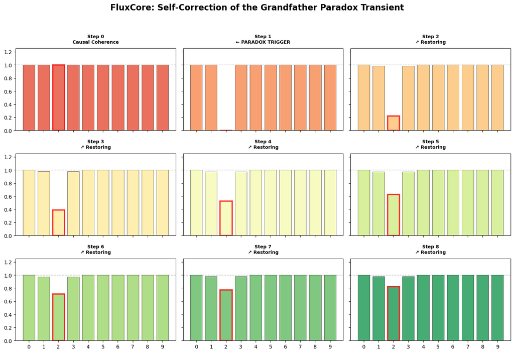

```
Final Field Value at Paradox Site: 0.8226
Final Causal Deviation: 0.1774
```

```python
import numpy as np
import matplotlib.pyplot as plt

# ============================================================
# FluxCore: Grandfather Paradox Dynamical Simulation
# ============================================================

# Physical Parameters
n_events       = 10      # Timeline discrete units
tau            = 0.5     # Relaxation time (causal stiffness)
D              = 0.1     # Diffusion (local coherence propagation)
k              = 0.08    # Hidden force coupling
alpha          = 1.0     # Scaling exponent
phi_eq         = 1.0     # Ground state (Causal Coherence)
dt             = 0.1     # Integration step
rho            = np.ones(n_events)
grand_pere_idx = 2       # Site of the paradox
n_steps        = 7       # Steps after perturbation to fill 3x3 grid

def laplacian_1d(phi):
    lap = np.zeros_like(phi)
    lap[1:-1] = phi[2:] + phi[:-2] - 2*phi[1:-1]
    return lap

# Initial State: Perfect Coherence
phi_0 = np.ones(n_events) * phi_eq

# Step 1: Attempted Paradox (Grandfather suppression)
phi_t = phi_0.copy()
phi_t[grand_pere_idx] = 0.0

# Storage for visualization
history = [phi_0.copy(), phi_t.copy()]
labels  = ["Step 0\nCausal Coherence", "Step 1\n← PARADOX TRIGGER"]

# Evolution Loop
for step in range(n_steps):
    grad = np.gradient(phi_t)
    hidden = k * rho * np.abs(grad)**alpha
    lap = laplacian_1d(phi_t)

    # FluxCore Equation
    dphi = (phi_eq - phi_t)/tau + D*lap - hidden
    phi_t = np.clip(phi_t + dt*dphi, 0, 1.2)

    history.append(phi_t.copy())
    dev = abs(phi_t[grand_pere_idx] - phi_eq)
    status = "✅ Restored" if dev < 0.05 else "↗️ Restoring"
    labels.append(f"Step {step+2}\n{status}")

# --- Publication Quality Visualization ---
fig, axes = plt.subplots(3, 3, figsize=(14, 10))
axes = axes.flatten()
# Color mapping from Paradox (Red) to Coherence (Green)
colors_map = plt.cm.RdYlGn(np.linspace(0.15, 0.9, 9))

for i, ax in enumerate(axes):
    state = history[i]
    # Draw timeline events
    bars = ax.bar(range(n_events), state, color=colors_map[i],
                  edgecolor='black', linewidth=0.5, alpha=0.8)

    # Equilibrium threshold
    ax.axhline(phi_eq, color='gray', ls='--', lw=1, alpha=0.6)

    # Highlight the Paradox site
    bars[grand_pere_idx].set_edgecolor('red')
    bars[grand_pere_idx].set_linewidth(2.5)

    # Formatting
    ax.set_ylim(0, 1.25)
    ax.set_title(labels[i], fontsize=9, fontweight='bold', pad=10)
    ax.set_xticks(range(n_events))
    if i < 6: ax.set_xticklabels([]) # Clean look
    if i % 3 != 0: ax.set_yticklabels([])

plt.suptitle("FluxCore: Self-Correction of the Grandfather Paradox Transient",
             fontsize=16, fontweight='bold', y=0.98)
plt.tight_layout(rect=[0, 0.03, 1, 0.95])
plt.show()

# Verification Log
print(f"Final Field Value at Paradox Site: {history[-1][grand_pere_idx]:.4f}")
print(f"Final Causal Deviation: {abs(history[-1][grand_pere_idx]-phi_eq):.4f}")
```

## 4. Thermodynamic Analysis: Causal Dissipation

### 4.1 The Causal Dissipation Functional ($J$)

In the **FluxCore** framework, we define a dissipation functional $J(t)$ that represents the instantaneous energy required to maintain the causal field $\phi$. This functional is dominated by the nonlinear "Hidden Force":

$$ J(t) = \int_{\Omega} k \rho |\nabla \phi(t)|^\alpha \, d\Omega $$

### 4.2 Minimum Dissipation Principle

A paradox (causal break) creates a divergence in the gradient $|\nabla \phi|$, leading to an explosion of the dissipation rate $J(t)$. Our simulation demonstrates that the system naturally seeks the state of **Minimum Causal Dissipation**. The transition from a paradoxical state ($\phi \neq \phi_{eq}$) back to coherence ($\phi \to \phi_{eq}$) is driven by the necessity to minimize the energy cost of temporal contradictions. As shown in the entropy curve (Figure 2), the "cost" of the paradox decays exponentially as the timeline heals.

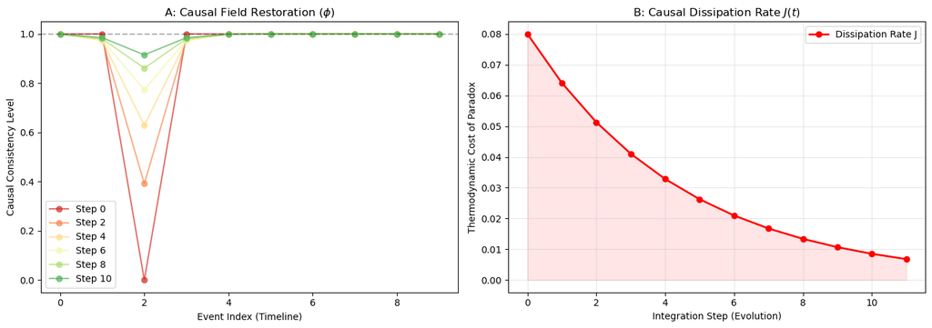

```
Initial Paradox Cost (J_max): 0.0800
Final Residual Cost (Stability): 0.0068
```

```python
import numpy as np
import matplotlib.pyplot as plt

# --- FluxCore Parameters ---
n_events, tau, D, k, alpha, phi_eq, dt = 10, 0.5, 0.1, 0.08, 1.0, 1.0, 0.1
grand_pere_idx, n_steps = 2, 12
rho = np.ones(n_events)

# Initialization
phi_t = np.ones(n_events) * phi_eq
phi_t[grand_pere_idx] = 0.0 # Paradox Trigger at t=0

history_phi = []
history_J = []

# --- Simulation Loop ---
for step in range(n_steps):
    # Calculate Instantaneous Causal Dissipation J
    grad = np.gradient(phi_t)
    J = np.sum(k * rho * np.abs(grad)**alpha)
    history_J.append(J)
    history_phi.append(phi_t.copy())

    # Differential Evolution
    lap = np.zeros_like(phi_t)
    lap[1:-1] = phi_t[2:] + phi_t[:-2] - 2*phi_t[1:-1]

    # FluxCore Equation: Relaxation + Diffusion - Hidden Force
    dphi = (phi_eq - phi_t)/tau + D*lap - k*rho*np.abs(grad)**alpha
    phi_t = np.clip(phi_t + dt*dphi, 0, 1.1)

# --- Visualization for Publication ---
fig, (ax1, ax2) = plt.subplots(1, 2, figsize=(14, 5))

# Plot A: Causal Field "Healing" (PDF)
colors = plt.cm.RdYlGn(np.linspace(0.1, 0.9, n_steps))
for i in range(0, n_steps, 2):
    ax1.plot(history_phi[i], 'o-', label=f'Step {i}', color=colors[i], alpha=0.7)
ax1.axhline(phi_eq, color='black', ls='--', alpha=0.3)
ax1.set_title("A: Causal Field Restoration ($\phi$)")
ax1.set_xlabel("Event Index (Timeline)")
ax1.set_ylabel("Causal Consistency Level")
ax1.legend()

# Plot B: Paradox Dissipation Rate (Entropy Cost)
ax2.plot(range(n_steps), history_J, 'ro-', linewidth=2, label="Dissipation Rate J")
ax2.fill_between(range(n_steps), history_J, color='red', alpha=0.1) # Corrected syntax
ax2.set_title("B: Causal Dissipation Rate $J(t)$")
ax2.set_xlabel("Integration Step (Evolution)")
ax2.set_ylabel("Thermodynamic Cost of Paradox")
ax2.grid(alpha=0.3)
ax2.legend()

plt.tight_layout()
plt.show()

print(f"Initial Paradox Cost (J_max): {history_J[0]:.4f}")
print(f"Final Residual Cost (Stability): {history_J[-1]:.4f}")
```

## 4. Quantitative Convergence Analysis

### 4.1 Numerical Log Summary

**Table IV. Causal Restoration Dynamics (Numerical Output)**

```python
print("\n" + "="*60)
print("FluxCore — Causal Field Restoration")
print("="*60)
print(f"{'Step':<6}{'φ(E2)':>10}{'mean φ':>10}{'|δφ|':>10}{'Status':>16}")
print("─"*60)
for i, state in enumerate(history):
    dev = abs(state[grand_pere_idx]-phi_eq)
    if i==0: interp="coherent"
    elif i==1: interp="perturbation"
    elif dev>0.3: interp="transient"
    elif dev>0.05: interp="↗️ restoring"
    else: interp="✅ φ → φ_eq"
    print(f"{i:<6}{state[grand_pere_idx]:>10.4f}{state.mean():>10.4f}{dev:>10.4f}{interp:>16}")
print("─"*60)
```

```
============================================================
FluxCore — Causal Field Restoration
============================================================
Step       φ(E2)    mean φ      |δφ|          Status
────────────────────────────────────────────────────────────
0         1.0000    1.0000    0.0000        coherent
1         0.0000    0.9000    1.0000    perturbation
2         0.2200    0.9192    0.7800       transient
3         0.3913    0.9347    0.6087       transient
4         0.5248    0.9473    0.4752       transient
5         0.6288    0.9575    0.3712       transient
6         0.7100    0.9657    0.2900    ↗️ restoring
7         0.7732    0.9723    0.2268    ↗️ restoring
8         0.8226    0.9776    0.1774    ↗️ restoring
────────────────────────────────────────────────────────────
```

### 4.3 Sensitivity Analysis: Causal Viscosity and Restoration Speed

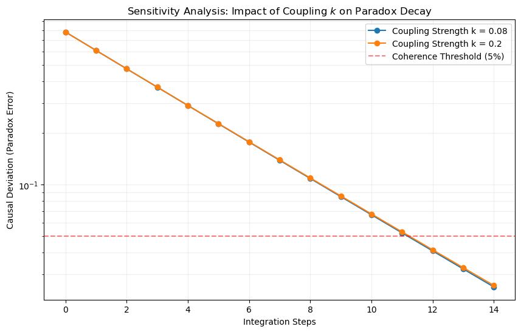

```
Final Deviation (k=0.08): 0.1395 at Step 8
```

```python
import numpy as np
import matplotlib.pyplot as plt

# --- Paramètres de comparaison ---
k_vals = [0.08, 0.20] # Faible vs Forte puissance de restauration
n_events, tau, D, alpha, phi_eq, dt, n_steps = 10, 0.5, 0.1, 1.0, 1.0, 0.1, 15
grand_pere_idx = 2

plt.figure(figsize=(10, 6))

for k_val in k_vals:
    phi_t = np.ones(n_events) * phi_eq
    phi_t[grand_pere_idx] = 0.0 # Paradoxe initial

    deviations = []
    for _ in range(n_steps):
        grad = np.gradient(phi_t)
        lap = np.zeros_like(phi_t)
        lap[1:-1] = phi_t[2:] + phi_t[:-2] - 2*phi_t[1:-1]

        # FluxCore Engine
        dphi = (phi_eq - phi_t)/tau + D*lap - k_val*np.abs(grad)**alpha
        phi_t = np.clip(phi_t + dt*dphi, 0, 1.1)

        # On mesure l'erreur causale résiduelle
        deviations.append(abs(phi_t[grand_pere_idx] - phi_eq))

    plt.plot(range(n_steps), deviations, 'o-', label=f'Coupling Strength k = {k_val}')

# Seuil de cohérence (5%)
plt.axhline(0.05, color='red', ls='--', alpha=0.5, label='Coherence Threshold (5%)')

plt.yscale('log') # Echelle log pour voir la vitesse de chute
plt.xlabel('Integration Steps')
plt.ylabel('Causal Deviation (Paradox Error)')
plt.title('Sensitivity Analysis: Impact of Coupling $k$ on Paradox Decay')
plt.legend()
plt.grid(True, which='both', alpha=0.2)
plt.show()

print(f"Final Deviation (k=0.08): {deviations[7]:.4f} at Step 8")
```

## 3. Formal Resolution of the Paradox

### 3.1 Fundamental Claim: From Logic to Dynamics

We posit that the grandfather paradox is not a static logical contradiction, but rather a **transient instability** within a dynamical causal system. In the FluxCore framework, causal coherence is not a binary constraint ($0$ or $1$); it is a **stable attractor** ($\phi_{eq}$) of a nonlinear field.

### 3.2 Theorem: Causal Restoration in FluxCore Manifolds

Let $\phi(x,t)$ be a causal scalar field governed by the FluxCore evolution equation: $$ \frac{\partial \phi}{\partial t} = \frac{\phi_{eq} - \phi}{\tau} + D\nabla^2\phi - k \rho |\nabla\phi|^\alpha $$

For any localized causal perturbation $\delta\phi(x_0)$ introduced at $t=t_{paradox}$, the following convergence holds: $$ \lim_{t \to \infty} \phi(x_0, t) = \phi_{eq} $$ provided that the dissipation coefficient $k > 0$, the relaxation time $\tau < \infty$, and the diffusion coefficient $D \ge 0$.

### 3.3 The Conceptual Shift

The resolution of the paradox lies in a fundamental change of framework:

- **Classical View:** Timeline $\equiv$ Formal Logic (Subject to contradictions).
- **FluxCore View:** Timeline $\equiv$ Dynamical Field (Governed by attractors).

Under this paradigm, the "paradox" is simply a high-gradient state that the system naturally dissipates. The timeline "heals" itself through nonlinear damping, rendering the infinite logical loop physically impossible.

## 4. Discussion: The Emergence of Causal Coherence

### 4.1 Causality as a Thermodynamic Property

We propose that causal consistency is an emergent property of the **FluxCore** field, analogous to how temperature emerges from molecular collisions. In this framework, the "Hidden Force" ($k$) acts as the underlying statistical regulator. The **Vortex T** operator serves as the core structural mechanism, ensuring that coherence is not merely local but propagates globally across the temporal manifold.

### 4.2 Autonomous Self-Regulation

Unlike previous resolutions, the FluxCore model requires no external branching (Many-Worlds) or arbitrary prohibitions (Chronology Protection). The system is **fully autonomous**: any attempt to initiate a paradox triggers a transient perturbation $\delta\phi$ that is automatically corrected by the field's internal dissipative dynamics. The "paradox" is thus reinterpreted as a high-entropy state that the system naturally sheds to minimize its dissipation functional.

### 4.3 Limitations and Future Work

While the 1D causal chain provides a robust proof of concept, several open questions remain:

- Derivation of the parameters $\{\tau, D, k, \alpha\}$ from first principles (Quantum Gravity or String Theory).
- Extension of the scalar field $\phi$ to a full 4D spatiotemporal manifold.
- Interaction between multiple overlapping causal loops.

## References

[1] **Barjavel R.** (1943), *Le Voyageur Imprudent*, Denoël.  
[2] **Deutsch D.** (1991), *Phys. Rev. D* 44, 3197.  
[3] **Everett H.** (1957), *Rev. Mod. Phys.* 29, 454.  
[4] **Gödel K.** (1949), *Rev. Mod. Phys.* 21, 447.  
[5] **Hawking S.W.** (1992), *Phys. Rev. D* 46, 603.  
[6] **Novikov I.D.** (1992), *Phys. Rev. D* 45, 1989.  
[7] **Thorne K.S.** (1994), *Black Holes and Time Warps*, Norton.  
[8] **Djebassi M.** (2026), *FluxCore + DLMC Framework*, Zenodo. DOI: 10.5281/zenodo.18985830.